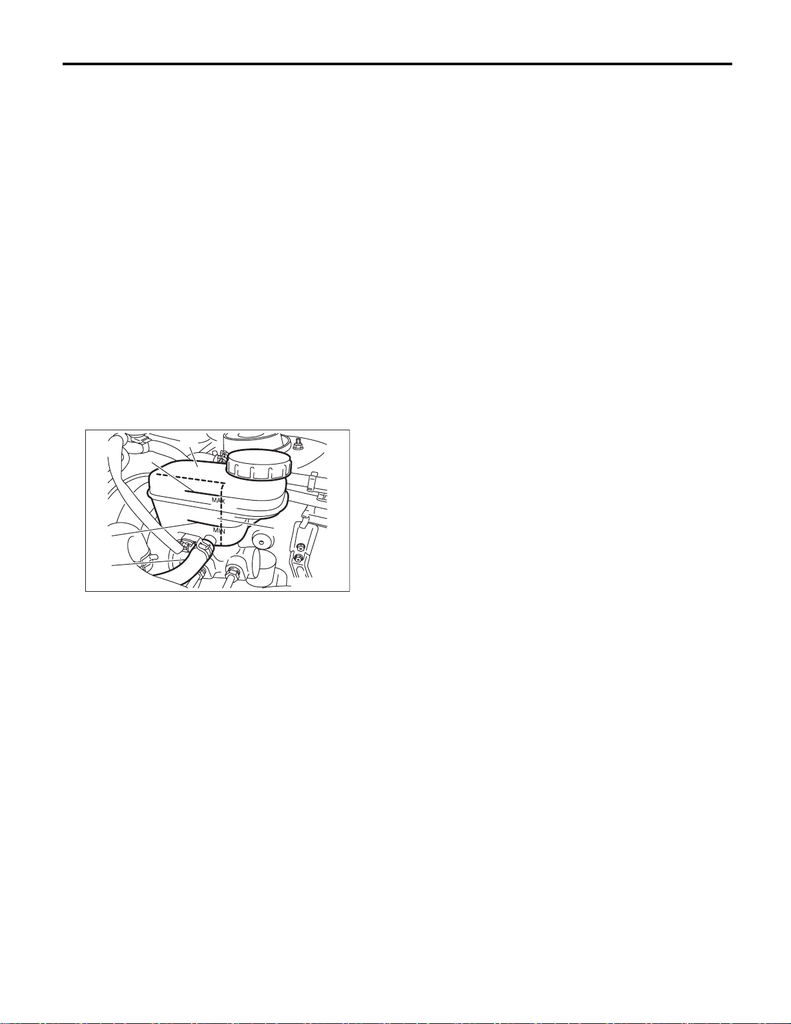

CL-28

Clutch Fluid

CLUTCH SYSTEM

8. Clutch Fluid

A: INSPECTION

CAUTION:

Be careful not to spill the brake fluid. Brake flu-

id spilled on the vehicle body will harm the

paint surface; wash it off with water and wipe

clean quickly if spilled.

1) Park the vehicle on a level surface.

2) Inspect the fluid level using the scale on the out-

side of the reservoir tank. If the level is below “MIN”,

add fluid to bring it up to “MAX”, and also inspect for

leakage.

CAUTION:

This reservoir tank has the brake fluid chamber

and the clutch fluid chamber. When checking

the fluid level, always check the fluid from the

clutch fluid chamber side where the tank hose

is connected.

Recommended brake fluid:

New FMVSS No. 116 DOT3 or DOT4

B: REPLACEMENT

CAUTION:

• Be careful not to spill the brake fluid. Brake

fluid spilled on the vehicle body will harm the

paint surface; wash it off with water and wipe

clean quickly if spilled.

• Use new FMVSS No. 116 DOT3 or DOT4.

• Cover the air breather with cloth to prevent

brake fluid from being splashed on surround-

ing parts when loosening the breather.

• Avoid mixing brake fluid of different brands

to prevent fluid performance from degrading.

• Be careful not to allow dirt or dust to enter the

reservoir tank.

NOTE:

• During the bleeding operation, keep the reservoir

tank filled with brake fluid to prevent entry of air.

• Clutch pedal must be operated very slowly.

• Bleed air from the oil line with help of a co-work-

er.

• The required amount of brake fluid is approxi-

mately 150 mL (5.1 US fl oz, 5.3 Imp fl oz) for total

clutch system.

1) Remove the intercooler. <Ref. to IN(STI)-13,

REMOVAL, Intercooler.> <Ref. to IN(w/o STI)-38,

REMOVAL, Intercooler.>

2) Drain the brake fluid from the air breather of the

operating cylinder.

3) Refill the reservoir tank with recommended

brake fluid.

Recommended brake fluid:

New FMVSS No. 116 DOT3 or DOT4

4) If necessary, bleed air from the clutch fluid. <Ref.

to CL-29, Clutch Fluid Air Bleeding.>

41, INSTALLATION, Intercooler.>

(A) Reservoir tank

(B) Clutch fluid chamber

(C) MAX. level

(D) MIN. level

(E) Tank hose

CL-00869

(A)

(C)

(B)

(D)

(E)